# Job ads posting frequency in rural NSW during COVID-19

This notebook answers a question from the DSI director: how did the posting frequencies change in rural NSW during COVID-19.

# Data loading and preparation

First, load the main data from the Burning Glass dataset.

# Volumes of job ads per SA4 regions

Since we are exploring the data, let’s what is the geographic granularity that we have in NSW. We count the number of jobads in each of the SA4 regions of NSW. Visibly, the Sydney region has the lion’s share of job ads.

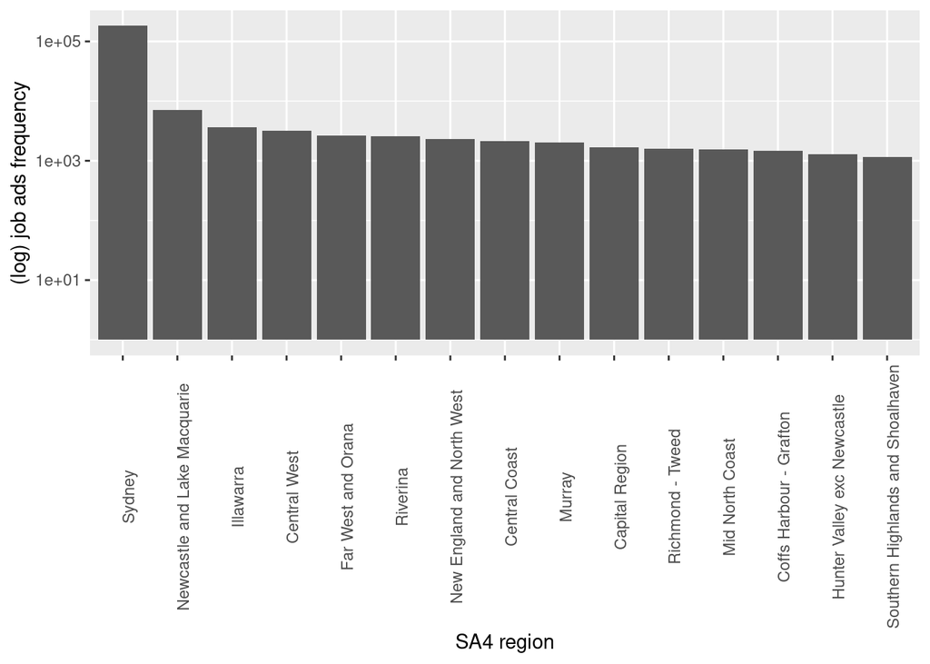

# Posting frequency per week

Let us now examine the posting dynamics of several of these regions. We decide to count job ads at the level of the week, as literature shows that jobad posting has a strong weekly and yearly seasonality. Let’s pick ‘Capital Region’ (around Canberra), ‘Illawarra’, ‘Far West and Orana’ and ‘Sydney’.

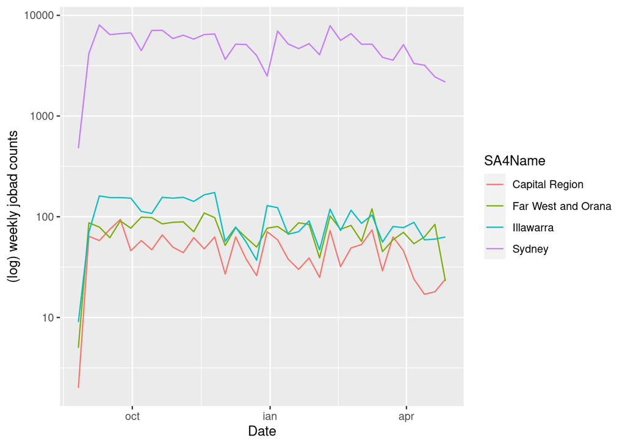

Lets us pick another four:

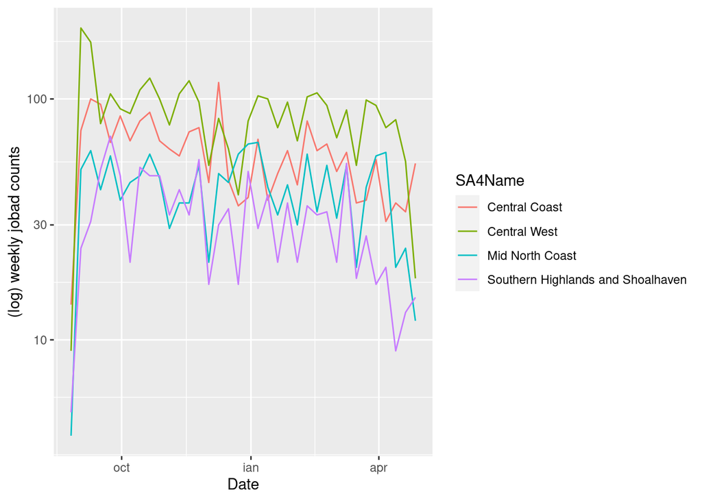

# Measuring the COVID-19 loss

This is exploratory analysis: we know that jobs decrease in March and April ’20 due to COVID-19. Job ads posting are known to have a strong yearly seasonality. Normally, job ads posting increases between Easter and until October, after which it decreases (see [this article](https://theconversation.com/coronavirus-infecting-australian-jobs-vacancy-rates-down-since-early-february-134234) for an analysis of yearly seasonality).

Here, we compare the CODIV-19 period (March-April ’20) to the same period of last year (March-April ’19). We define the COVID-19 loss as: let $\bar{B}_i$ be the mean number of jobads per week in region $i$ before COVID-19: March-April ’19; let $\bar{A}_i$ be the mean number of jobads per week in region $i$ during COVID-19: March-April’20. We compute the COVID-19 loss as
$$loss = \frac{\bar{B}_i - \bar{A}_i}{\bar{B}_i}$$
We employ the above-define loss measure to measure the relative decrease in jobads posting between the two periods. We can compute the mean number of weekly job postings before and after COVID, and find the regions hardest hit by comparing the two. Here is how the different regions in NSW looks like:

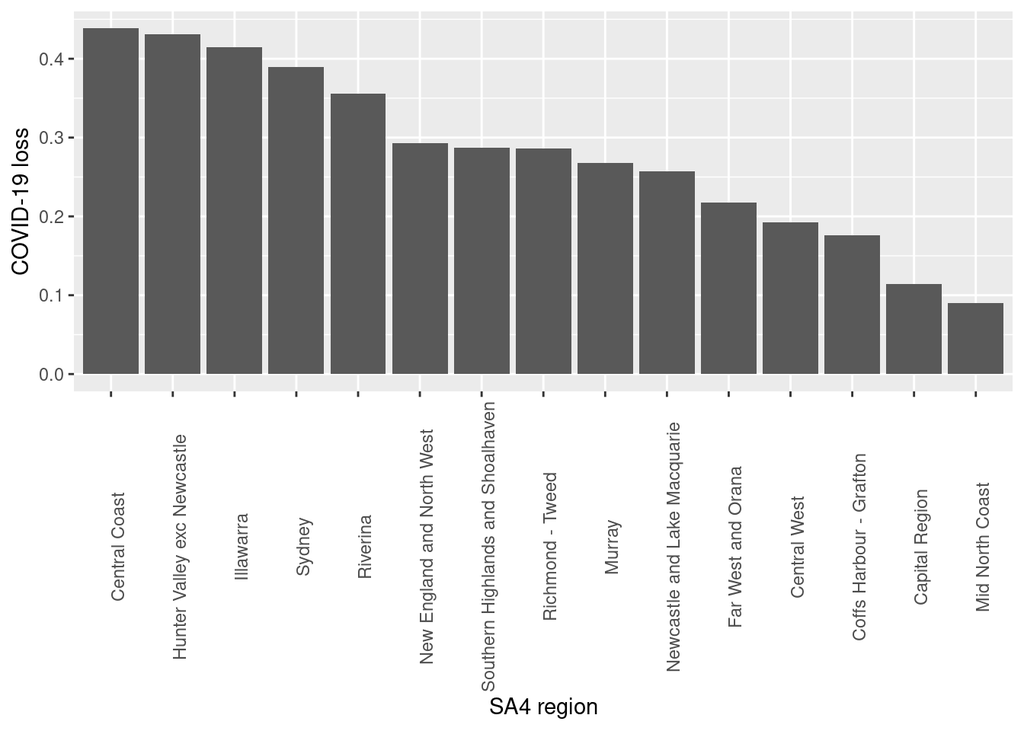

# Preview of hardest hit regions

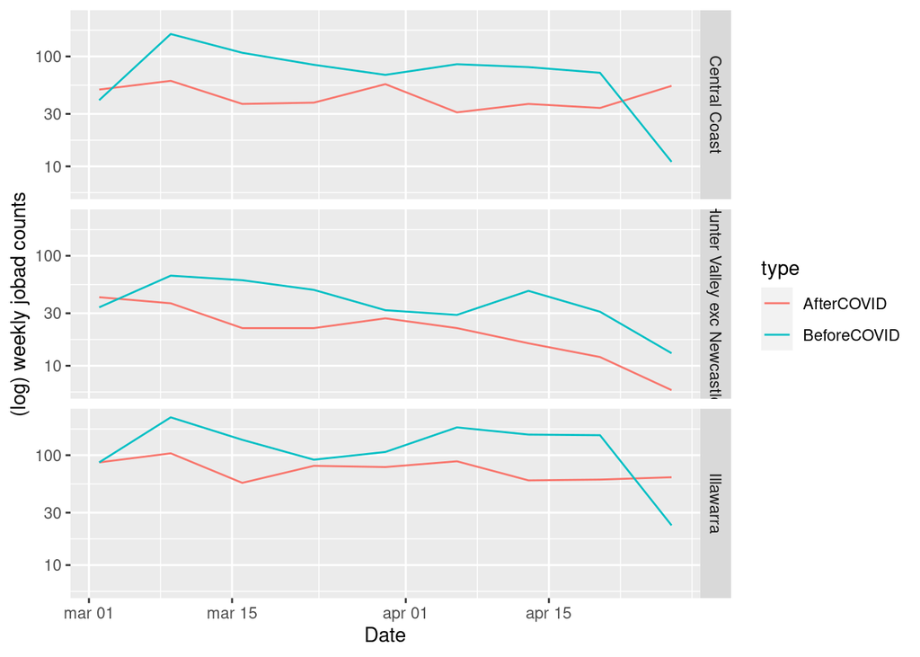

# Preview of least impacted regions

We look at the posting frequency for the bottom 3 most hard hit regions (i.e. least impacted): ‘Capital Region’, ‘Coffs Harbour - Grafton’ and ‘Mid North Coast’. We notice interesting inversion trends, and for the ‘Mid North Coast’, there were significantly higher posting frequencies during COVID at the end of March and beginning of April.

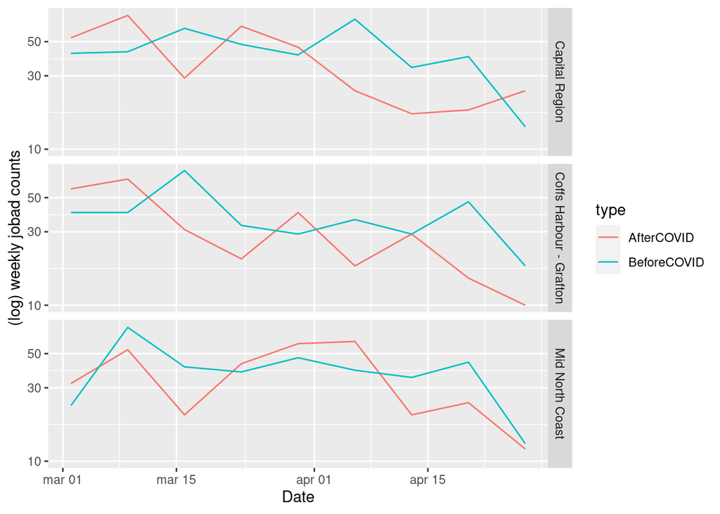